# Exploring_XYZ

# EDA

### First part of formal EDA should be to get a high level understanding of each feature

```python
cols = ['building_type','vacancy_level','has_online_tour','photo_quality','lead_volume']
```

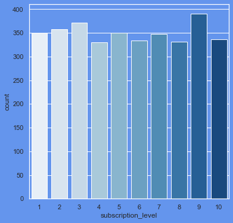

```python
# Interesting to note that there isn't a major delta between subcription_level counts

sns.set(rc={'figure.figsize':(6,6),'axes.facecolor':'cornflowerblue','figure.facecolor':'cornflowerblue'})
sns.axes_style("darkgrid")
sns.countplot(x='subscription_level',data=df,palette='Blues')
```

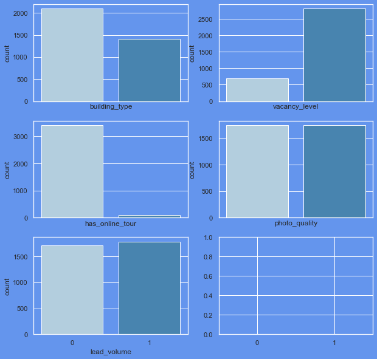

```python
# A few interesting notes here:

# Online tours have very little impact on lead generation,
# which could prove an important observation when looking at
# customer spend.

# It makes sense that a high vacancy rate could be a result
# of increased leads. Something to examine in our feature correlation analysis.

f, axes = plt.subplots(3, 2, figsize=(10, 10), sharex=True)
sns.set(rc={'axes.facecolor':'cornflowerblue', 'figure.facecolor':'cornflowerblue'})
sns.set_style("darkgrid")
sns.countplot(x='building_type',data=df,palette='Blues',ax=axes[0, 0]);
sns.countplot(x='vacancy_level',data=df,palette='Blues', ax=axes[0, 1])
sns.countplot(x='has_online_tour',data=df,palette='Blues', ax=axes[1, 0])
sns.countplot(x='photo_quality',data=df,palette='Blues', ax=axes[1, 1])
sns.countplot(x='lead_volume',data=df,palette='Blues', ax=axes[2, 0])
```

### It makes sense to look at subscription levels by city, when companies sign up throughout the year, & at what subscription level

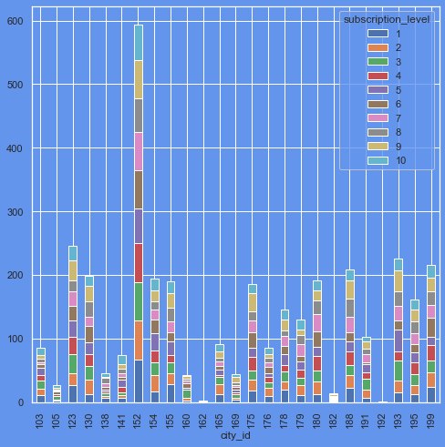

```python
# City 152 has nearly 3x the number of subscriptions vs the other cities in the dataset
# with a fairly equal distribution of all 10 subscription levels.
# The table shows that while there is a big difference in total number of subscriptions
# between cities, it appears that all levels are respresented and there isn't a huge
# disparity between each.

df_plot = df.groupby(['subscription_level', 'city_id']).size().reset_index().pivot(columns='subscription_level', index='city_id', values=0)
sns.set(rc={'figure.figsize':(8,8),'axes.facecolor':'cornflowerblue','figure.facecolor':'cornflowerblue'})
df_plot.plot(kind='bar', stacked=True)
```

```python
df_plot2 = df[['sign_up_date','subscription_level']]
df_plot2['sign_up_month'] = df_plot2['sign_up_date'].dt.month
df_plot2.drop('sign_up_date',axis=1,inplace=True)
df_plot2=df_plot2.sort_values(by='sign_up_month')
df_plot2.head()
```

|  | subscription_level | sign_up_month |
| --- | --- | --- |
| 2200 | 7 | 1 |
| 476 | 1 | 1 |
| 2422 | 2 | 1 |
| 2061 | 7 | 1 |
| 965 | 2 | 1 |

```python
df_plot2=df_plot2.sort_values(by='sign_up_month')

df_plot3 = df_plot2.groupby('sign_up_month').count().subscription_level
df_plot3
```

```
sign_up_month
1     268
2     218
3     309
4     229
5     265
6     228
7     290
8     346
9     303
10    390
11    338
12    316
Name: subscription_level, dtype: int64
```

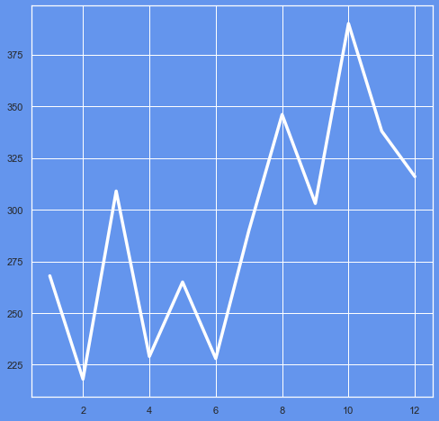

```python
# Given the seasonality of the renters market in general,
# we thought it important to examine trends by month. This
# chart is a bit strange in that the summer months are usually
# the hottest time in the rental market, and we'd expect
# an upward trend to begin in May in preparation. In this case, however,
# things don't get going until June and peak in August. The
# peak of cycle in October also makes very little sense.

# It is also important to note here that the scale distorts
# the absolute numbers as evidenced in the following chart.

sns.lineplot(data=df_plot3,color='white', linewidth=3.5)
```

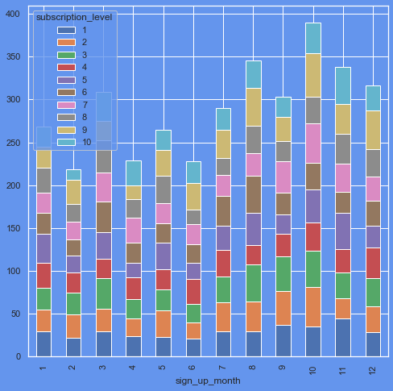

```python
# These stacked bars present a more normalized view of the subscription
# sign-up dynamics. However, the odd trends discussed above remain albeit
# visually more muted.

# Again, we think it's notable that the spread between subscription levels is
# not drastically different between months.

df_plot4 = df_plot2.groupby(['subscription_level', 'sign_up_month']).size().reset_index().pivot(columns='subscription_level', index='sign_up_month', values=0)
sns.set(rc={'figure.figsize':(8,8),'axes.facecolor':'cornflowerblue','figure.facecolor':'cornflowerblue'})
df_plot4.plot(kind='bar', stacked=True)
```

# Correlation and Models

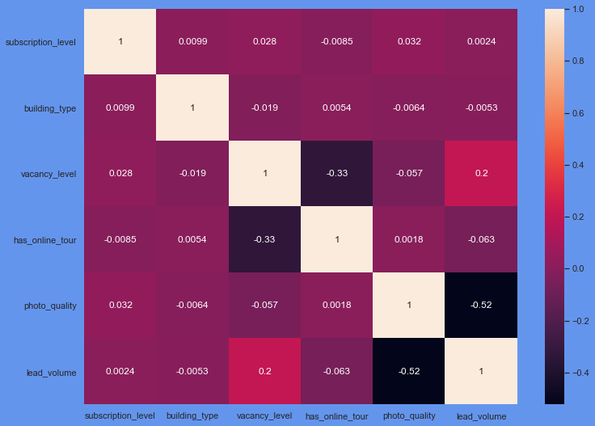

```python
# Overall the data is not highly correlated and no indication
# of multicollinearity.
# As suspected, the highest positive correlation here exists between
# vacancy levels and lead volume.
# Somewhat strange (but interesting) is the high negative correlation between photo
# quality and lead volume.

plt.figure(figsize=(12,9))
sns.set(rc={'figure.facecolor':'cornflowerblue'})
sns.heatmap(df.corr(), annot=True)
```

### There are a few choices to explore further through modeling, but we chose to predict the level of lead volume (medium vs high) using logistic regression

```python
X = df[['building_type','vacancy_level','has_online_tour','photo_quality']]
y = df[['lead_volume']]
```

```python
from sklearn.model_selection import train_test_split
X_train, X_test, y_train, y_test = train_test_split(X, y, test_size=0.3, random_state=101)
```

```python
log_reg = sm.Logit(y_train, X_train).fit()
```

```
Optimization terminated successfully.
         Current function value: 0.518339
         Iterations 6
```

```python
# We chose Statsmodels' Logit Regression package in order to be able to
# determine the statistical significance of our features using P-values.
# The model tells us that building_type and has_online_tour have P-values
# well-outside our .05 conventional threshold. Meanwhile, vacancy_level and
# photo_quality are both statistically significant and their coefficients
# together explain the majority of the relationship with the target.

# The caveat here is that our features are mostly categorical, which
# should be taken into consideration when explaining the actual relationships.

print(log_reg.summary())
```

```
                           Logit Regression Results
==============================================================================
Dep. Variable:            lead_volume   No. Observations:                 2450
Model:                          Logit   Df Residuals:                     2446
Method:                           MLE   Df Model:                            3
Date:                Fri, 03 Sep 2021   Pseudo R-squ.:                  0.2521
Time:                        01:34:34   Log-Likelihood:                -1269.9
converged:                       True   LL-Null:                       -1698.0
Covariance Type:            nonrobust   LLR p-value:                2.965e-185
===================================================================================
                      coef    std err          z      P>|z|      [0.025      0.975]
-----------------------------------------------------------------------------------
building_type       0.0234      0.095      0.245      0.806      -0.164       0.210
vacancy_level       1.5318      0.086     17.800      0.000       1.363       1.700
has_online_tour     0.2438      0.314      0.777      0.437      -0.371       0.859
photo_quality      -2.4611      0.099    -24.866      0.000      -2.655      -2.267
===================================================================================
```

```python
yhat = log_reg.predict( X_test)
prediction = list(map(round, yhat))
```

```python
from sklearn.metrics import (confusion_matrix,accuracy_score)

# confusion matrix
cm = confusion_matrix(y_test, prediction)
print ("Confusion Matrix : \n", cm)

# accuracy score of the model
print('Test accuracy = ', accuracy_score(y_test, prediction))
```

```
Confusion Matrix :
 [[394 113]
 [163 380]]
Test accuracy =  0.7371428571428571
```

```python
# Even though the "psuedo r-squared" was pretty terrible,
# our model performed fairly well in both precision & recall.
# The only thing left to do at this point is to remove the
# statistically insignificant features and re-run our model to
# see if we can improve it further.

from sklearn.metrics import classification_report
print(classification_report(y_test,prediction))
```

```
              precision    recall  f1-score   support

           0       0.71      0.78      0.74       507
           1       0.77      0.70      0.73       543

    accuracy                           0.74      1050
   macro avg       0.74      0.74      0.74      1050
weighted avg       0.74      0.74      0.74      1050
```

```python
X1 = df[['vacancy_level','photo_quality']]
y1 = df[['lead_volume']]
```

```python
X1_train, X1_test, y1_train, y1_test = train_test_split(X1, y1, test_size=0.3, random_state=101)
log_reg1 = sm.Logit(y1_train, X1_train).fit()
print(log_reg1.summary())
```

```
Optimization terminated successfully.
         Current function value: 0.518486
         Iterations 6
                           Logit Regression Results
==============================================================================
Dep. Variable:            lead_volume   No. Observations:                 2450
Model:                          Logit   Df Residuals:                     2448
Method:                           MLE   Df Model:                            1
Date:                Fri, 03 Sep 2021   Pseudo R-squ.:                  0.2519
Time:                        01:34:34   Log-Likelihood:                -1270.3
converged:                       True   LL-Null:                       -1698.0
Covariance Type:            nonrobust   LLR p-value:                4.946e-188
=================================================================================
                    coef    std err          z      P>|z|      [0.025      0.975]
---------------------------------------------------------------------------------
vacancy_level     1.5361      0.078     19.577      0.000       1.382       1.690
photo_quality    -2.4526      0.099    -24.890      0.000      -2.646      -2.259
=================================================================================
```

```python
yhat1 = log_reg1.predict( X1_test)
prediction1 = list(map(round, yhat1))
```

```python
# confusion matrix
cm = confusion_matrix(y1_test, prediction1)
print ("Confusion Matrix : \n", cm)

# accuracy score of the model
print('Test accuracy = ', accuracy_score(y1_test, prediction1))
```

```
Confusion Matrix :
 [[411  96]
 [186 357]]
Test accuracy =  0.7314285714285714
```

```python
# We can see that removing the two features made our model slightly worse,
# invariably due to providing less information

print(classification_report(y1_test,prediction1))
```

```
              precision    recall  f1-score   support

           0       0.69      0.81      0.74       507
           1       0.79      0.66      0.72       543

    accuracy                           0.73      1050
   macro avg       0.74      0.73      0.73      1050
weighted avg       0.74      0.73      0.73      1050
```